# MP3

Volodymyr Kotov, Milan Vannik, Serhii Marinchenko

2023-02-04

```r
library(tidyverse)
library(readxl)
library(xts)
library(tseries)
library(foreign)
library(tsibble)
library(tsibbledata)
library(feasts)
library(fable)
library(urca)
library(dplyr)
library(astsa)
library(ggplot2)
library(forecast)
library(lubridate)
library(zoo)
library(rugarch)
```

```r
setwd("~/Desktop/KSE/Econometrics III")
data_1 <- read_excel("CMO-Historical-Data-Monthly.xlsx", sheet = "Monthly Prices", skip = 4) %>%
  mutate(
    `Coal, Australian` = as.numeric(`Coal, Australian **`),
    `Coal, South African` = as.numeric(`Coal, South African **`)
  ) %>%
  select(`Coal, Australian`, `Coal, South African`) %>%
  filter( !is.na(`Coal, South African`)) %>%
  mutate(date = seq(as.Date("1984-01-01"), length = 468, by = "month"))
data_1 <- data_1 %>%
  mutate(Date = yearmonth(date))

data_1_tsb <- data_1 %>%
  as_tsibble(index = Date)

#lets separate 10 observations

data_2_tsb <- data_1_tsb[1:(nrow(data_1_tsb)-10),]

data_au_ts <- data_2_tsb %>%
  select(., `Coal, Australian`, Date)

data_saf_ts <- data_2_tsb %>%
  select(., `Coal, South African`, Date)
```

### Model fit

```r
fit_au <- data_au_ts %>%
  model(arima110_au = ARIMA(`Coal, Australian` ~ pdq(1,1,0)+ PDQ(0,0,0)),
        arima210_au = ARIMA(`Coal, Australian` ~ pdq(2,1,0)+ PDQ(0,0,0)),
        arima111_au = ARIMA(`Coal, Australian` ~ pdq(1,1,1)+ PDQ(0,0,0)),
        arima511_au = ARIMA(`Coal, Australian` ~ PDQ(0,0,0), stepwise = FALSE, greedy = FALSE))

glance(fit_au)
```

```
## # A tibble: 4 × 8
##   .model      sigma2 log_lik   AIC  AICc   BIC ar_roots  ma_roots
##   <chr>        <dbl>   <dbl> <dbl> <dbl> <dbl> <list>    <list>
## 1 arima110_au   44.1  -1513. 3030. 3030. 3038. <cpl [1]> <cpl [0]>
## 2 arima210_au   44.0  -1512. 3030. 3030. 3043. <cpl [2]> <cpl [0]>
## 3 arima111_au   44.0  -1512. 3030. 3030. 3042. <cpl [1]> <cpl [1]>
## 4 arima511_au   42.7  -1504. 3022. 3022. 3050. <cpl [5]> <cpl [1]>
```

```r
data_3_tsb <- data_1_tsb[(nrow(data_1_tsb)-9):nrow(data_1_tsb),]
```

### Holdback forecast evaluation

```r
forecast_h10 <- fit_au %>% fabletools::forecast(h = 10)

fabletools::accuracy(forecast_h10, data_1_tsb) %>%
  select(.model | ME:RMSSE)
```

```
## # A tibble: 4 × 8
##   .model         ME  RMSE   MAE   MPE  MAPE  MASE RMSSE
##   <chr>       <dbl> <dbl> <dbl> <dbl> <dbl> <dbl> <dbl>
## 1 arima110_au  149.  153.  149.  39.3  39.3  9.71  5.64
## 2 arima111_au  141.  146.  141.  37.4  37.4  9.22  5.36
## 3 arima210_au  145.  150.  145.  38.3  38.3  9.46  5.50
## 4 arima511_au  145.  149.  145.  38.3  38.3  9.44  5.47
```

Using holdback data of 10 observations, we can see that the model with minimized loss is arima111.

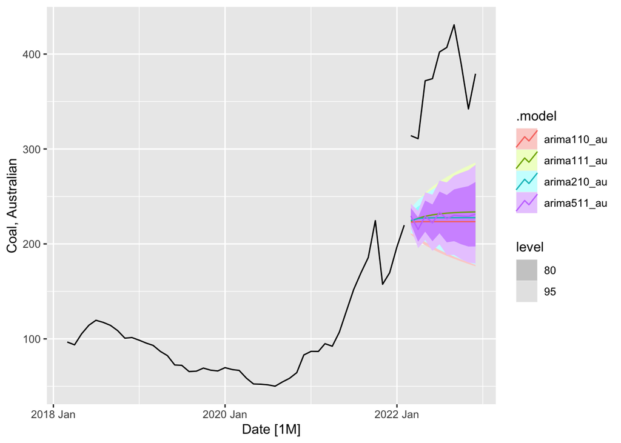

```r
data_test_au <- data_3_tsb %>%
  select(., `Coal, Australian`, Date)

data_au_ts_plot <- data_au_ts %>%
  filter_index("2018 Mar " ~ "2022 Feb")

autoplot(data_au_ts_plot) + autolayer(forecast_h10) + autolayer(data_test_au)
```

### Calculate bias

```r
Volat_au_110 <- data_3_tsb$`Coal, Australian` - forecast_h10$.mean[1:10]
Volat_au_210 <- data_3_tsb$`Coal, Australian` - forecast_h10$.mean[11:20]
Volat_au_111 <- data_3_tsb$`Coal, Australian` - forecast_h10$.mean[21:30]
Volat_au_511 <- data_3_tsb$`Coal, Australian` - forecast_h10$.mean[31:40]

print(paste("The estimate of ARIMA(1, 1, 0) bias is", as.character(mean(Volat_au_110))))
```

```
## [1] "The estimate of ARIMA(1, 1, 0) bias is 148.787444603652"
```

```r
print(paste("The estimate of ARIMA(2, 1, 0) bias is", as.character(mean(Volat_au_210))))
```

```
## [1] "The estimate of ARIMA(2, 1, 0) bias is 145.019709434297"
```

```r
print(paste("The estimate of ARIMA(1, 1, 1) bias is", as.character(mean(Volat_au_111))))
```

```
## [1] "The estimate of ARIMA(1, 1, 1) bias is 141.371385826232"
```

```r
print(paste("The estimate of ARIMA(5, 1, 1) bias is", as.character(mean(Volat_au_511))))
```

```
## [1] "The estimate of ARIMA(5, 1, 1) bias is 144.607574172225"
```

```r
fit_resid_arima110 <- lm(Volat_au_110 ~ forecast_h10$.mean[1:10])
fit_resid_arima210 <- lm(Volat_au_210 ~ forecast_h10$.mean[11:20])
fit_resid_arima111 <- lm(Volat_au_111 ~ forecast_h10$.mean[21:30])
fit_resid_arima511 <- lm(Volat_au_511 ~ forecast_h10$.mean[31:40])

summary(fit_resid_arima110)
```

```
##
## Call:
## lm(formula = Volat_au_110 ~ forecast_h10$.mean[1:10])
##
## Residuals:
##     Min      1Q  Median      3Q     Max
## -59.615  -7.394   3.365  18.164  49.856
##
## Coefficients:
##                           Estimate Std. Error t value Pr(>|t|)
## (Intercept)              -32402.66   15445.41  -2.098   0.0692 .
## forecast_h10$.mean[1:10]    145.70      69.13   2.108   0.0681 .
## ---
## Signif. codes:  0 '***' 0.001 '**' 0.01 '*' 0.05 '.' 0.1 ' ' 1
##
## Residual standard error: 33.41 on 8 degrees of freedom
## Multiple R-squared:  0.357,  Adjusted R-squared:  0.2766
## F-statistic: 4.442 on 1 and 8 DF,  p-value: 0.06814
```

```r
summary(fit_resid_arima210)
```

```
##
## Call:
## lm(formula = Volat_au_210 ~ forecast_h10$.mean[11:20])
##
## Residuals:
##     Min      1Q  Median      3Q     Max
## -48.111  -7.113   0.699  17.596  46.285
##
## Coefficients:
##                           Estimate Std. Error t value Pr(>|t|)
## (Intercept)               -6003.90    2417.46  -2.484   0.0379 *
## forecast_h10$.mean[11:20]    27.07      10.64   2.544   0.0345 *
## ---
## Signif. codes:  0 '***' 0.001 '**' 0.01 '*' 0.05 '.' 0.1 ' ' 1
##
## Residual standard error: 30.55 on 8 degrees of freedom
## Multiple R-squared:  0.4471, Adjusted R-squared:  0.378
## F-statistic:  6.47 on 1 and 8 DF,  p-value: 0.03452
```

```r
summary(fit_resid_arima111)
```

```
##
## Call:
## lm(formula = Volat_au_111 ~ forecast_h10$.mean[21:30])
##
## Residuals:
##     Min      1Q  Median      3Q     Max
## -53.756 -14.676   2.562  19.452  40.366
##
## Coefficients:
##                            Estimate Std. Error t value Pr(>|t|)
## (Intercept)               -1645.174    699.755  -2.351   0.0466 *
## forecast_h10$.mean[21:30]     7.740      3.031   2.553   0.0340 *
## ---
## Signif. codes:  0 '***' 0.001 '**' 0.01 '*' 0.05 '.' 0.1 ' ' 1
##
## Residual standard error: 29.25 on 8 degrees of freedom
## Multiple R-squared:  0.449,  Adjusted R-squared:  0.3801
## F-statistic: 6.519 on 1 and 8 DF,  p-value: 0.034
```

```r
summary(fit_resid_arima511)
```

```
##
## Call:
## lm(formula = Volat_au_511 ~ forecast_h10$.mean[31:40])
##
## Residuals:
##     Min      1Q  Median      3Q     Max
## -65.283 -12.371   0.987  19.343  48.790
##
## Coefficients:
##                           Estimate Std. Error t value Pr(>|t|)
## (Intercept)               -494.320    522.025  -0.947    0.371
## forecast_h10$.mean[31:40]    2.807      2.293   1.224    0.256
##
## Residual standard error: 36.02 on 8 degrees of freedom
## Multiple R-squared:  0.1578, Adjusted R-squared:  0.05251
## F-statistic: 1.499 on 1 and 8 DF,  p-value: 0.2557
```

When regressing fitted values onto errors of the model, both the intercept and the slope have quite low p-values. Conclusion: the model biased.

### Forecast for 2023

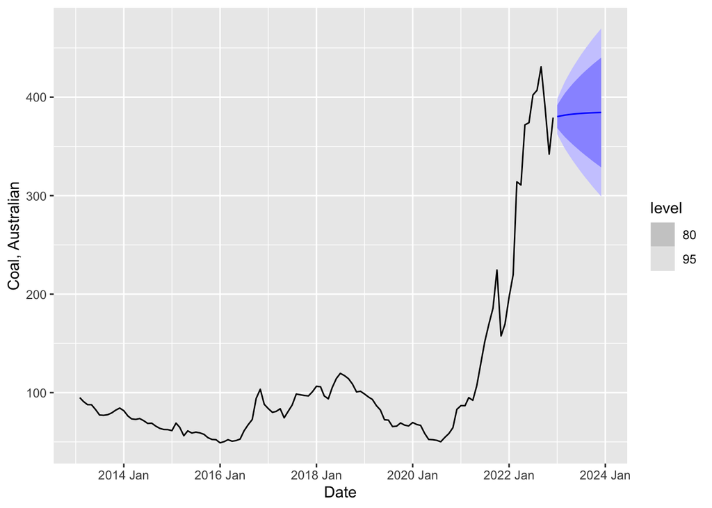

```r
data_au_ts_fore2023 <- data_1_tsb %>%
  select(., `Coal, Australian`, Date)

fit_au_forecast <- data_au_ts_fore2023 %>%
  model(
    arima111_au = ARIMA(`Coal, Australian` ~ pdq(1,1,1)+ PDQ(0,0,0))
  )


forecast_au_h12 <- fit_au_forecast %>%
  select(arima111_au) %>%
  fabletools::forecast(h = 12)

forecast_au_h12 %>% autoplot() + autolayer(data_au_ts_fore2023[350:nrow(data_au_ts_fore2023),])
```

```r
forecast_au_h12
```

```
## # A fable: 12 x 4 [1M]
## # Key:     .model [1]
##    .model          Date `Coal, Australian` .mean
##    <chr>          <mth>             <dist> <dbl>
##  1 arima111_au 2023 Jan         N(380, 82)  380.
##  2 arima111_au 2023 Feb        N(381, 184)  381.
##  3 arima111_au 2023 Mar        N(382, 305)  382.
##  4 arima111_au 2023 Apr        N(382, 441)  382.
##  5 arima111_au 2023 May        N(383, 591)  383.
##  6 arima111_au 2023 Jun        N(383, 753)  383.
##  7 arima111_au 2023 Jul        N(384, 926)  384.
##  8 arima111_au 2023 Aug       N(384, 1107)  384.
##  9 arima111_au 2023 Sep       N(384, 1296)  384.
## 10 arima111_au 2023 Oct       N(384, 1490)  384.
## 11 arima111_au 2023 Nov       N(384, 1690)  384.
## 12 arima111_au 2023 Dec       N(384, 1895)  384.
```

### Residuals diagnostics

```r
Box.test(Volat_au_111, lag = 7)
```

```
##
##  Box-Pierce test
##
## data:  Volat_au_111
## X-squared = 6.2809, df = 7, p-value = 0.5074
```

Cannot reject H0 of independence in residuals.

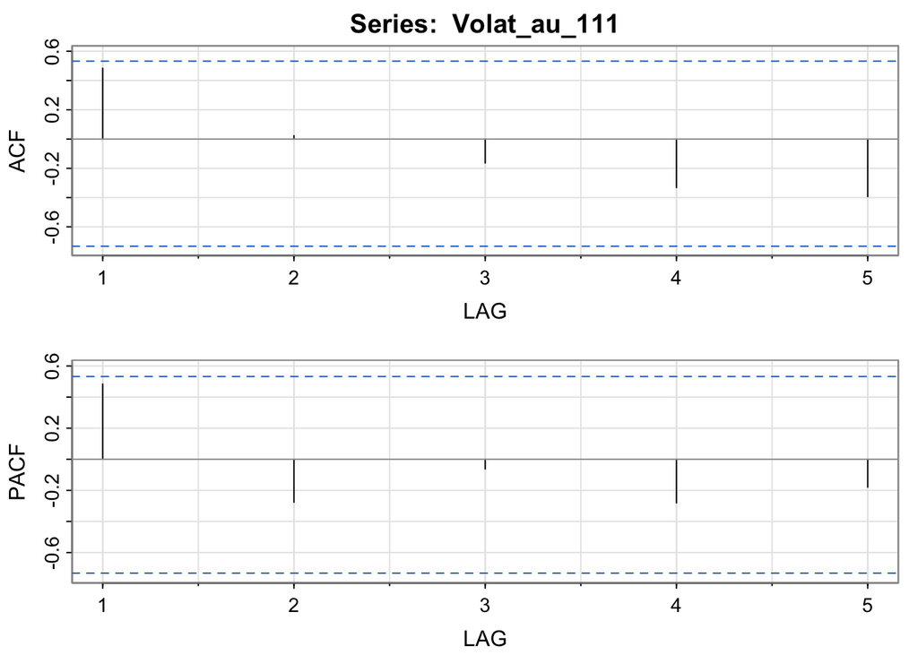

```
##      [,1]  [,2]  [,3]  [,4]  [,5]
## ACF  0.48  0.02 -0.16 -0.33 -0.39
## PACF 0.48 -0.28 -0.06 -0.28 -0.18
```

```r
acf2(Volat_au_111)
```

### The same for South African coal

```r
fit_saf <- data_saf_ts %>%
  model(arima110_saf = ARIMA(`Coal, South African` ~ pdq(1,1,0)+ PDQ(0,0,0)),
        arima210_saf = ARIMA(`Coal, South African` ~ pdq(2,1,0)+ PDQ(0,0,0)),
        arima111_saf = ARIMA(`Coal, South African` ~ pdq(1,1,1)+ PDQ(0,0,0)),
        arima511_saf = ARIMA(`Coal, South African` ~ PDQ(0,0,0), stepwise = FALSE, greedy = FALSE))
```

```r
forecast_saf_h10 <- fit_saf %>% fabletools::forecast(h = 10)

fabletools::accuracy(forecast_saf_h10, data_1_tsb) %>%
  select(.model | ME:RMSSE)
```

```
## # A tibble: 4 × 8
##   .model          ME  RMSE   MAE   MPE  MAPE  MASE RMSSE
##   <chr>        <dbl> <dbl> <dbl> <dbl> <dbl> <dbl> <dbl>
## 1 arima110_saf  116.  117.  116.  36.8  36.8  8.49  4.91
## 2 arima111_saf  108.  109.  108.  34.3  34.3  7.92  4.58
## 3 arima210_saf  111.  112.  111.  35.2  35.2  8.13  4.70
## 4 arima511_saf  122.  123.  122.  38.7  38.7  8.93  5.16
```

[figure not shown]

```r
data_test_saf <- data_3_tsb %>%
  select(., `Coal, Australian`, Date)

data_saf_ts_plot <- data_saf_ts %>%
  filter_index("2018 Mar " ~ "2022 Feb")

autoplot(data_saf_ts_plot) + autolayer(forecast_h10) + autolayer(data_test_saf)
```

```r
Volat_saf_110 <- data_3_tsb$`Coal, South African` - forecast_saf_h10$.mean[1:10]
Volat_saf_210 <- data_3_tsb$`Coal, South African` - forecast_saf_h10$.mean[11:20]
Volat_saf_111 <- data_3_tsb$`Coal, South African` - forecast_saf_h10$.mean[21:30]
Volat_saf_511 <- data_3_tsb$`Coal, South African` - forecast_saf_h10$.mean[31:40]

print(paste("The estimate of ARIMA(1, 1, 0) bias is", as.character(mean(Volat_saf_110))))
```

```
## [1] "The estimate of ARIMA(1, 1, 0) bias is 115.688821226632"
```

```r
print(paste("The estimate of ARIMA(2, 1, 0) bias is", as.character(mean(Volat_saf_210))))
```

```
## [1] "The estimate of ARIMA(2, 1, 0) bias is 110.801349197592"
```

```r
print(paste("The estimate of ARIMA(1, 1, 1) bias is", as.character(mean(Volat_saf_111))))
```

```
## [1] "The estimate of ARIMA(1, 1, 1) bias is 107.962601673429"
```

```r
print(paste("The estimate of ARIMA(5, 1, 1) bias is", as.character(mean(Volat_saf_511))))
```

```
## [1] "The estimate of ARIMA(5, 1, 1) bias is 121.73375484527"
```

```r
fit_resid_arima110_saf <- lm(Volat_saf_110 ~ forecast_saf_h10$.mean[1:10])
fit_resid_arima210_saf <- lm(Volat_saf_210 ~ forecast_saf_h10$.mean[11:20])
fit_resid_arima111_saf <- lm(Volat_saf_111 ~ forecast_saf_h10$.mean[21:30])
fit_resid_arima511_saf <- lm(Volat_saf_511 ~ forecast_saf_h10$.mean[31:40])

summary(fit_resid_arima110_saf)
```

```
##
## Call:
## lm(formula = Volat_saf_110 ~ forecast_saf_h10$.mean[1:10])
##
## Residuals:
##     Min      1Q  Median      3Q     Max
## -35.553  -1.450   3.995   9.457  14.225
##
## Coefficients:
##                              Estimate Std. Error t value Pr(>|t|)
## (Intercept)                  -81841.3    62127.1  -1.317    0.224
## forecast_saf_h10$.mean[1:10]    414.7      314.4   1.319    0.224
##
## Residual standard error: 15.56 on 8 degrees of freedom
## Multiple R-squared:  0.1787, Adjusted R-squared:  0.076
## F-statistic:  1.74 on 1 and 8 DF,  p-value: 0.2236
```

```r
summary(fit_resid_arima210_saf)
```

```
##
## Call:
## lm(formula = Volat_saf_210 ~ forecast_saf_h10$.mean[11:20])
##
## Residuals:
##     Min      1Q  Median      3Q     Max
## -34.456  -1.907   4.156   8.175  13.017
##
## Coefficients:
##                                Estimate Std. Error t value Pr(>|t|)
## (Intercept)                   -1454.591    989.056  -1.471    0.180
## forecast_saf_h10$.mean[11:20]     7.730      4.884   1.583    0.152
##
## Residual standard error: 14.52 on 8 degrees of freedom
## Multiple R-squared:  0.2385, Adjusted R-squared:  0.1433
## F-statistic: 2.505 on 1 and 8 DF,  p-value: 0.1521
```

```r
summary(fit_resid_arima111_saf)
```

```
##
## Call:
## lm(formula = Volat_saf_111 ~ forecast_saf_h10$.mean[21:30])
##
## Residuals:
##     Min      1Q  Median      3Q     Max
## -24.858  -0.587   1.538   3.842  14.906
##
## Coefficients:
##                               Estimate Std. Error t value Pr(>|t|)
## (Intercept)                   -489.960    227.875  -2.150   0.0638 .
## forecast_saf_h10$.mean[21:30]    2.912      1.110   2.624   0.0305 *
## ---
## Signif. codes:  0 '***' 0.001 '**' 0.01 '*' 0.05 '.' 0.1 ' ' 1
##
## Residual standard error: 10.75 on 8 degrees of freedom
## Multiple R-squared:  0.4626, Adjusted R-squared:  0.3954
## F-statistic: 6.886 on 1 and 8 DF,  p-value: 0.03045
```

```r
summary(fit_resid_arima511_saf)
```

```
##
## Call:
## lm(formula = Volat_saf_511 ~ forecast_saf_h10$.mean[31:40])
##
## Residuals:
##     Min      1Q  Median      3Q     Max
## -34.624  -7.308   5.896  11.322  16.086
##
## Coefficients:
##                               Estimate Std. Error t value Pr(>|t|)
## (Intercept)                    260.433    329.939   0.789    0.453
## forecast_saf_h10$.mean[31:40]   -0.724      1.722  -0.420    0.685
##
## Residual standard error: 17.15 on 8 degrees of freedom
## Multiple R-squared:  0.02162,    Adjusted R-squared:  -0.1007
## F-statistic: 0.1768 on 1 and 8 DF,  p-value: 0.6852
```

```r
#Box.test(Volat_saf$.resid, lag = 7)
```

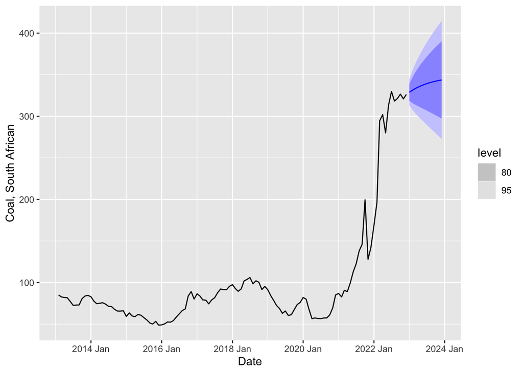

```r
data_saf_ts_fore2023 <- data_1_tsb %>%
  select(., `Coal, South African`, Date)

fit_saf_forecast <- data_saf_ts_fore2023 %>%
  model(
    arima111_au = ARIMA(`Coal, South African` ~ pdq(1,1,1)+ PDQ(0,0,0))
  )


forecast_saf_h12 <- fit_saf_forecast %>%
  select(arima111_au) %>%
  fabletools::forecast(h = 12)

forecast_saf_h12 %>% autoplot() + autolayer(data_saf_ts_fore2023[350:nrow(data_saf_ts_fore2023),])
```

# Part II

Table of contents for the second part: - Check for ARCH effect in our data - plot graphs of ACF, PACF, residuals and squared residuals - Select the needed parameters for our model (both for AU and SAF) - Complete tests to see of our models are satisfactory - Recomplete forecast and plot results

### Check for ARCH effect in our data:

As well as we selected arima111 for both categories of prices, we will proceed with this specification. Just for the report not to take 1000+ lines of codes, we will stick only to a AU coal prices keeping in mind that the same procedure could be done for SAF prices on coal as well. However, as well as we cannot get residuals of forecasted models, we will use our models on our whole data

For AU:

Lets check that visually

Model creation:

```r
arima_au_111 <- arima(data_au_ts_fore2023$`Coal, Australian`, order = c(1,1,1))

resid_au <- arima_au_111$residuals
resid_au_sq <- resid_au^2
```

ACF:

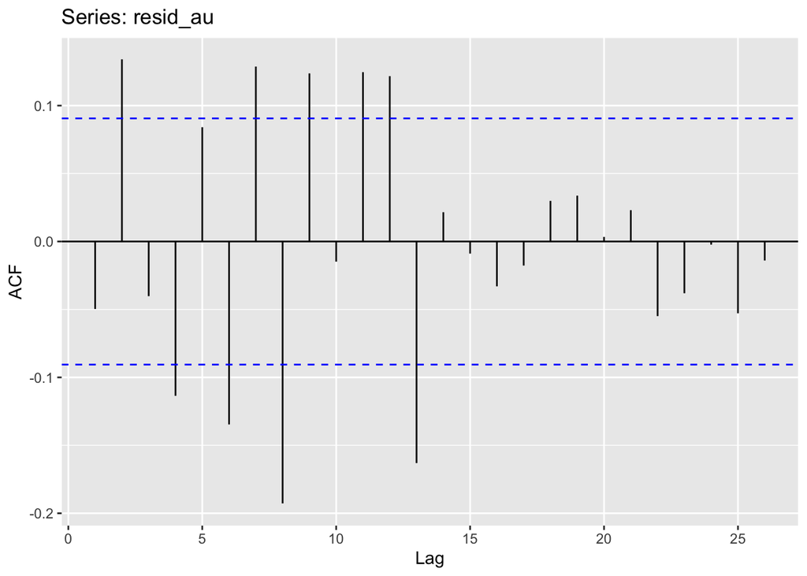

```r
ggAcf(resid_au)
```

PACF:

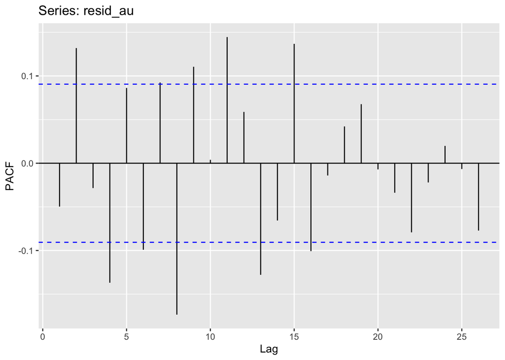

```r
ggPacf(resid_au)
```

Even if that is negotiable somehow, the next graphs will deal with all the debates.

ACF for squared residuals:

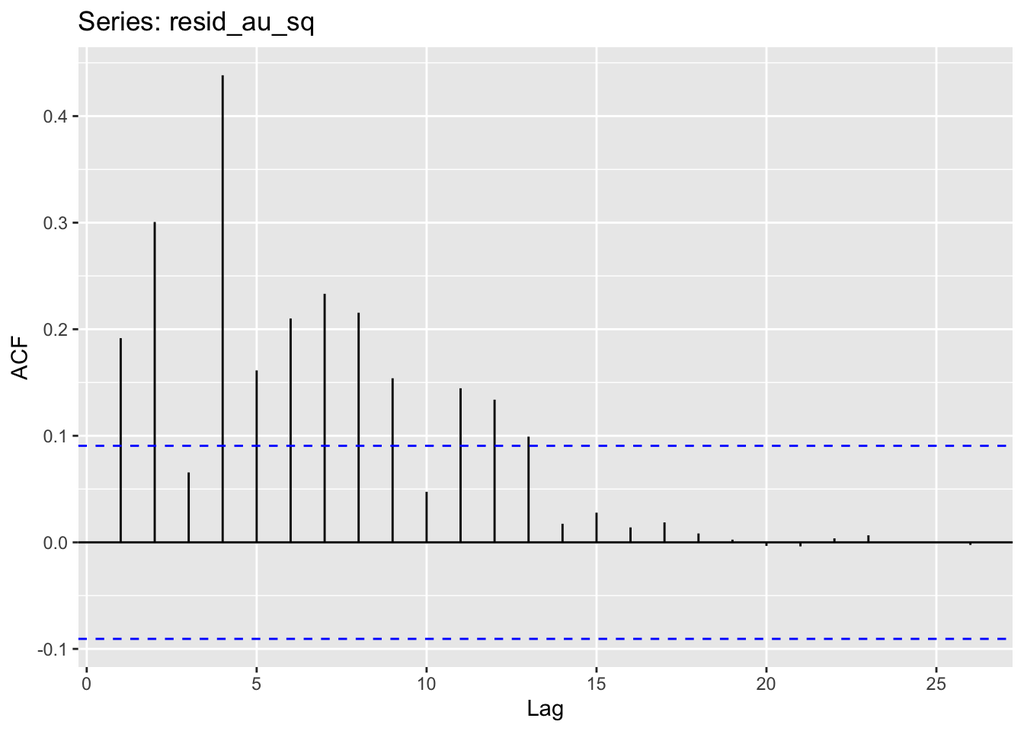

```r
ggAcf(resid_au_sq)
```

PACF for squared residuals:

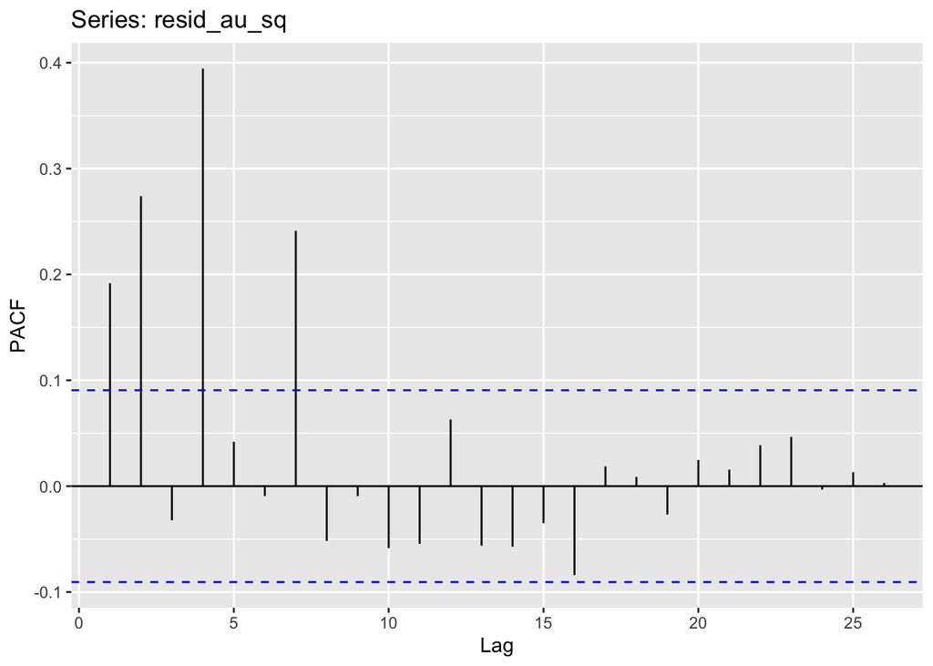

```r
ggPacf(resid_au_sq)
```

As we can see, there is an autocorrelation function on acf and pacf that we can get from residuals squared.

One more proof:

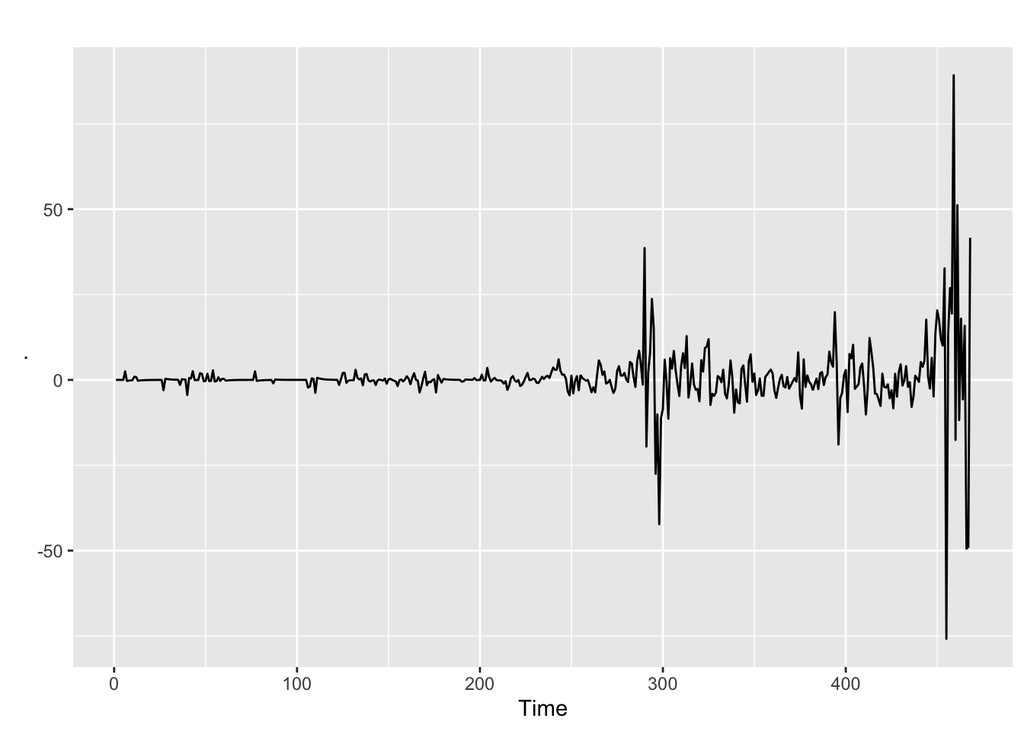

```r
resid_au %>% autoplot()
```

For sure ARCH exists. Lets prove that formally.

```r
lag_au <- as.integer(round(log(nrow(data_au_ts_fore2023)),0))
FinTS::ArchTest(residuals(arima_au_111), lags=lag_au)
```

```
##
##  ARCH LM-test; Null hypothesis: no ARCH effects
##
## data:  residuals(arima_au_111)
## Chi-squared = 126.42, df = 6, p-value < 2.2e-16
```

**Result:** low p-value. ARCH exists. Lets deal with it.

We will try to evaluate what we have on the following models: GARCH(1,1), ARCH(2), ARCH(1). But, as stated by our TA and by the same statement from the book, GARCH(1,1) actually can catch high autoregressive orders, so we will not use any ARCH(3)+.

As well as GARCH model do not work with differenced models, we need to settle our data already differenced.

```r
data_au_ts_fore2023_copy <- data_au_ts_fore2023
data_au_ts_fore2023_copy$au_price_diff <- NA
view(data_au_ts_fore2023_copy)

for (i in (2:(nrow(data_au_ts_fore2023_copy)))) {
  data_au_ts_fore2023_copy$au_price_diff[i] <- data_au_ts_fore2023_copy$`Coal, Australian`[i] - data_au_ts_fore2023_copy$`Coal, Australian`[i-1]
}

data_au_ts_fore2023_copy$au_price_diff[1] <- 0

data_au_test <- data_au_ts_fore2023_copy[1:(nrow(data_au_ts_fore2023_copy)-10),]
data_au_check <- data_au_ts_fore2023_copy[(nrow(data_au_ts_fore2023_copy)-9):nrow(data_au_ts_fore2023_copy),]
```

### GARCH(1,1)

```r
garch1_1Spec_au = ugarchspec(variance.model=list(model="sGARCH", garchOrder=c(1,1)),
              mean.model=list(armaOrder=c(1,1),
              include.mean=T))

garch1_1Fit_au <- ugarchfit(spec = garch1_1Spec_au, data = data_au_test$au_price_diff)
print(garch1_1Fit_au)
```

```
##
## *---------------------------------*
## *          GARCH Model Fit        *
## *---------------------------------*
##
## Conditional Variance Dynamics
## -----------------------------------
## GARCH Model  : sGARCH(1,1)
## Mean Model   : ARFIMA(1,0,1)
## Distribution : norm
##
## Optimal Parameters
## ------------------------------------
##         Estimate  Std. Error  t value Pr(>|t|)
## mu     -0.068362    0.078500 -0.87086 0.383830
## ar1     0.334386    0.526244  0.63542 0.525154
## ma1    -0.230213    0.541760 -0.42494 0.670884
## omega   0.197283    0.046034  4.28557 0.000018
## alpha1  0.298167    0.032767  9.09962 0.000000
## beta1   0.700833    0.032077 21.84877 0.000000
##
## Robust Standard Errors:
##         Estimate  Std. Error  t value Pr(>|t|)
## mu     -0.068362    0.101523 -0.67337 0.500714
## ar1     0.334386    0.812995  0.41130 0.680851
## ma1    -0.230213    0.830336 -0.27725 0.781586
## omega   0.197283    0.086278  2.28660 0.022219
## alpha1  0.298167    0.048750  6.11621 0.000000
## beta1   0.700833    0.051502 13.60788 0.000000
##
## LogLikelihood : -1099.547
##
## Information Criteria
## ------------------------------------
##
## Akaike       4.8277
## Bayes        4.8818
## Shibata      4.8274
## Hannan-Quinn 4.8490
##
```

[output cut: 43 more lines]

```
## Negative Sign Bias   1.171 0.2422
## Positive Sign Bias   1.236 0.2171
## Joint Effect         3.419 0.3315
##
##
## Adjusted Pearson Goodness-of-Fit Test:
## ------------------------------------
##   group statistic p-value(g-1)
## 1    20     557.7   4.122e-106
## 2    30     770.8   1.515e-143
## 3    40     587.4    4.855e-99
## 4    50     855.8   8.614e-148
##
##
## Elapsed time : 0.04667997
```

## **Ljung-Box Test on Standardized Squared Residuals**

**lags that were used:** 1, 5, 9 **result:** on all of the lags above the p-value is to high, what does not allows us to reject the null hypothesis that states that we have no correlation

## **Ljung-Box Test on Standardized Residuals**

**lags that were used:** 1,5,9 **result:** No serial correlation cannot be stated because of low p-value on all of the lags

## **ARCH test**

**lags that were used:** 3,5,7 **result:** on all of the lags above, the p-value is too high, so we cannot reject H0 that states that we have no ARCH effect

**AIC:** 4.8277 **BIC:** 4.8818

### ARCH(1)

```r
arch1Spec_au = ugarchspec(variance.model=list(model="sGARCH", garchOrder=c(1,0)),
              mean.model=list(armaOrder=c(1,1),
              include.mean=T))

arch1Fit_au <- ugarchfit(spec = arch1Spec_au, data = data_au_test$au_price_diff)
print(arch1Fit_au)
```

```
##
## *---------------------------------*
## *          GARCH Model Fit        *
## *---------------------------------*
##
## Conditional Variance Dynamics
## -----------------------------------
## GARCH Model  : sGARCH(1,0)
## Mean Model   : ARFIMA(1,0,1)
## Distribution : norm
##
## Optimal Parameters
## ------------------------------------
##         Estimate  Std. Error   t value Pr(>|t|)
## mu       0.17203    1.705460   0.10087  0.91965
## ar1      1.00000    0.028741  34.79321  0.00000
## ma1     -0.83855    0.033213 -25.24774  0.00000
## omega    3.65497    0.532331   6.86597  0.00000
## alpha1   0.99900    0.087074  11.47302  0.00000
##
## Robust Standard Errors:
##         Estimate  Std. Error   t value Pr(>|t|)
## mu       0.17203     9.51627  0.018078 0.985577
## ar1      1.00000     0.18562  5.387397 0.000000
## ma1     -0.83855     0.19591 -4.280362 0.000019
## omega    3.65497     2.44026  1.497776 0.134191
## alpha1   0.99900     0.39911  2.503070 0.012312
##
## LogLikelihood : -1238.446
##
## Information Criteria
## ------------------------------------
##
## Akaike       5.4299
## Bayes        5.4749
## Shibata      5.4297
## Hannan-Quinn 5.4476
##
## Weighted Ljung-Box Test on Standardized Residuals
## ------------------------------------
```

[output cut: 40 more lines]

```
## Negative Sign Bias  0.1570 0.8753
## Positive Sign Bias  0.5878 0.5570
## Joint Effect        1.3016 0.7287
##
##
## Adjusted Pearson Goodness-of-Fit Test:
## ------------------------------------
##   group statistic p-value(g-1)
## 1    20     189.4    4.269e-30
## 2    30     209.5    3.032e-29
## 3    40     221.8    1.990e-27
## 4    50     236.8    2.018e-26
##
##
## Elapsed time : 0.06312799
```

## **Ljung-Box Test on Standardized Squared Residuals**

**lags that were used:** 1, 2, 5 **result:** No serial correlation can be stated because of high p-value on first two lags, but it is present on the fifth lag on the 10% s.l.

## **Ljung-Box Test on Standardized Residuals**

**lags that were used:** 1,5,9 **result:** No serial correlation on the first and the ninth lag. However, it is present on the fifth lag.

## **ARCH test**

**lags that were used:** 2,4,6 **result:** on the second lag the p-value is high enough not to reject H0. On the fourth and the sixth lags, the p-value is too low, so we **can reject H0** that states that we have no ARCH effect

**AIC:** 5.4299 **BIC:** 5.4749

### ARCH(2)

```r
arch2Spec_au = ugarchspec(variance.model=list(model="sGARCH", garchOrder=c(2,0)),
              mean.model=list(armaOrder=c(1,1),
              include.mean=T))

arch2Fit_au <- ugarchfit(spec = arch2Spec_au, data = data_au_test$au_price_diff)
print(arch2Fit_au)
```

```
##
## *---------------------------------*
## *          GARCH Model Fit        *
## *---------------------------------*
##
## Conditional Variance Dynamics
## -----------------------------------
## GARCH Model  : sGARCH(2,0)
## Mean Model   : ARFIMA(1,0,1)
## Distribution : norm
##
## Optimal Parameters
## ------------------------------------
##         Estimate  Std. Error  t value Pr(>|t|)
## mu      -0.18096    0.101740  -1.7786 0.075305
## ar1      0.65206    0.092818   7.0251 0.000000
## ma1     -0.58230    0.097386  -5.9792 0.000000
## omega    2.01853    0.252101   8.0068 0.000000
## alpha1   0.31638    0.054368   5.8191 0.000000
## alpha2   0.68262    0.070573   9.6726 0.000000
##
## Robust Standard Errors:
##         Estimate  Std. Error  t value Pr(>|t|)
## mu      -0.18096    0.151329  -1.1958 0.231785
## ar1      0.65206    0.131868   4.9448 0.000001
## ma1     -0.58230    0.102447  -5.6838 0.000000
## omega    2.01853    0.661196   3.0528 0.002267
## alpha1   0.31638    0.076019   4.1618 0.000032
## alpha2   0.68262    0.194468   3.5102 0.000448
##
## LogLikelihood : -1162.005
##
## Information Criteria
## ------------------------------------
##
## Akaike       5.1005
## Bayes        5.1545
## Shibata      5.1001
## Hannan-Quinn 5.1217
##
```

[output cut: 43 more lines]

```
## Negative Sign Bias   1.573 0.116464
## Positive Sign Bias   1.879 0.060893   *
## Joint Effect        10.914 0.012200  **
##
##
## Adjusted Pearson Goodness-of-Fit Test:
## ------------------------------------
##   group statistic p-value(g-1)
## 1    20     552.3   5.689e-105
## 2    30     767.8   6.482e-143
## 3    40     878.6   4.815e-159
## 4    50     802.9   5.756e-137
##
##
## Elapsed time : 0.07655001
```

## **Ljung-Box Test on Standardized Squared Residuals**

**lags that were used:** 1, 5, 9 **result:** No serial correlation can be stated because of low p-value on the all of the lags.

## **Ljung-Box Test on Standardized Residuals**

**lags that were used:** 1,5,9 **result:** No serial correlation cannot be stated because of small p-value on all of the lags

## **ARCH test**

**lags that were used:** 3,5,7 **result:** on all of the lags above, the p-value is too low, so we **can reject H0** that states that we have no ARCH effect

**AIC:** 5.1005 **BIC:** 5.1545

### **Conclusion**

We will proceed with the only GARCH(1,1) as it is the only one that has no ARCH effect byt the test results and has the lowest AIC and BIC criteria.

### Remodeling with GARCH(1,1):

```r
# Forecasting

forecast_garch_au <- ugarchboot(garch1_1Fit_au, method = c("Partial","Full")[1],
                            n.ahead = 10, n.bootpred = 1000, n.bootfit = 1000)

f_garch_au <- forecast_garch_au@forc@forecast$seriesFor

sigma_au <- forecast_garch_au@forc@forecast$sigmaFor[1]
high_au <- f_garch_au + 1.96*sigma_au
low_au <- f_garch_au - 1.96*sigma_au
```

For a beautiful graph, lets create a dataframe:

```r
data_au_ts_fore2023_copy[(nrow(data_au_ts_fore2023_copy)-10),]
```

```
## # A tsibble: 1 x 3 [1M]
##   `Coal, Australian`     Date au_price_diff
##                <dbl>    <mth>         <dbl>
## 1               220. 2022 Feb          22.8
```

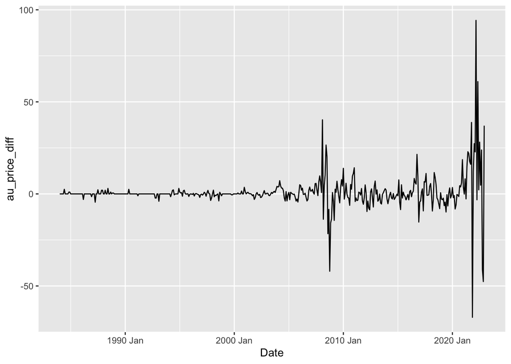

```r
x <- seq(as.Date("2022-03-01"), as.Date("2022-12-31"), by = "1 month")
Date <- yearmonth(x)
au_price_diff <- f_garch_au

data_for_rbind_au <- as.data.frame(f_garch_au,Date)

data_for_rbind_au2 <- data_au_ts_fore2023_copy[,c("au_price_diff","Date")]

ggplot(data_for_rbind_au2, aes(x=Date,y=au_price_diff)) +
  geom_line()
```

```r
data_au_test[(nrow(data_au_test)-1):nrow(data_au_test),]
```

```
## # A tsibble: 2 x 3 [1M]
##   `Coal, Australian`     Date au_price_diff
##                <dbl>    <mth>         <dbl>
## 1               197. 2022 Jan          27.3
## 2               220. 2022 Feb          22.8
```

```r
data_model_au_wo_diff <- data_for_rbind_au
data_model_au_wo_diff
```

```
##          1971-04-04 03:00:00
## 2022 Mar          2.96868296
## 2022 Apr          0.94718415
## 2022 May          0.27122262
## 2022 Jun          0.04519034
## 2022 Jul         -0.03039176
## 2022 Aug         -0.05566538
## 2022 Sep         -0.06411654
## 2022 Oct         -0.06694249
## 2022 Nov         -0.06788744
## 2022 Dec         -0.06820343
```

```r
data_model_au_wo_diff <- data_model_au_wo_diff %>%
  rename(., 'au_price_no_diff' = `1971-04-04 03:00:00`)

data_model_au_wo_diff$au_price_no_diff[1] <- data_model_au_wo_diff$au_price_no_diff[1] + data_au_test$`Coal, Australian`[nrow(data_au_test)]

for (t in (2:10)) {
  data_model_au_wo_diff$au_price_no_diff[t] = data_model_au_wo_diff$au_price_no_diff[t] + data_model_au_wo_diff$au_price_no_diff[t-1]
}

data_model_au_wo_diff$Date <- rownames(data_model_au_wo_diff)

data_au_test_1 <- data_au_test[,c('Coal, Australian',"Date")]

data_model_au_wo_diff <- data_model_au_wo_diff %>%
  mutate(Date = yearmonth(Date))

df_test <- dplyr::bind_rows(data_au_test_1,data_model_au_wo_diff)

typeof(data_au_test_1)
```

```
## [1] "list"
```

```r
typeof(data_model_au_wo_diff)
```

```
## [1] "list"
```

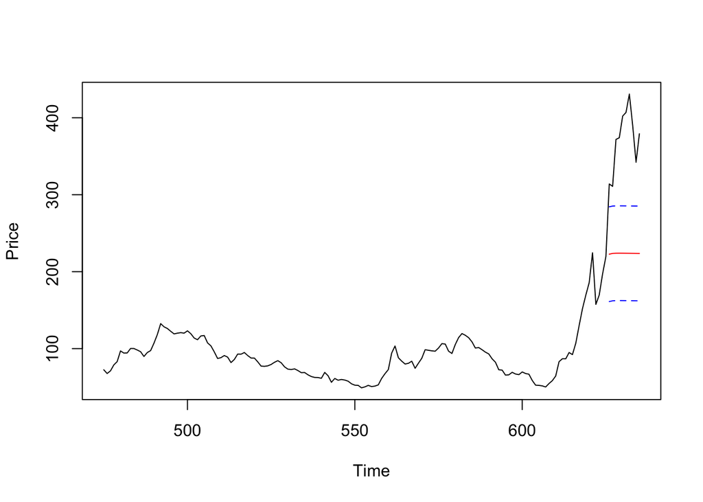

```r
low_au_check <- data_model_au_wo_diff$au_price_no_diff - 1.96*forecast_garch_au@fsigma[1]
high_au_check <- data_model_au_wo_diff$au_price_no_diff + 1.96*forecast_garch_au@fsigma[1]

date <- rownames(data_model_au_wo_diff)
bands <- data.frame(date,low_au_check,high_au_check)

bands <- bands %>%
  mutate(Date = yearmonth(date))

plot(x=data_au_ts_fore2023_copy$Date[308:468],y=data_au_ts_fore2023_copy$`Coal, Australian`[308:468],type='l', xlab = "Time", ylab = "Price")
lines(x=data_model_au_wo_diff$Date,y=data_model_au_wo_diff$au_price_no_diff,type='l',col='red')
lines(x=bands$Date, y=bands$low_au_check,type='l',col='blue', lty=2)
lines(x=bands$Date, y=bands$high_au_check,type='l',col='blue', lty=2)
```

Lets compare visually to what we had before:

```
## Plot variable not specified, automatically selected `.vars = Coal, Australian`
## Plot variable not specified, automatically selected `.vars = Coal, Australian`
```

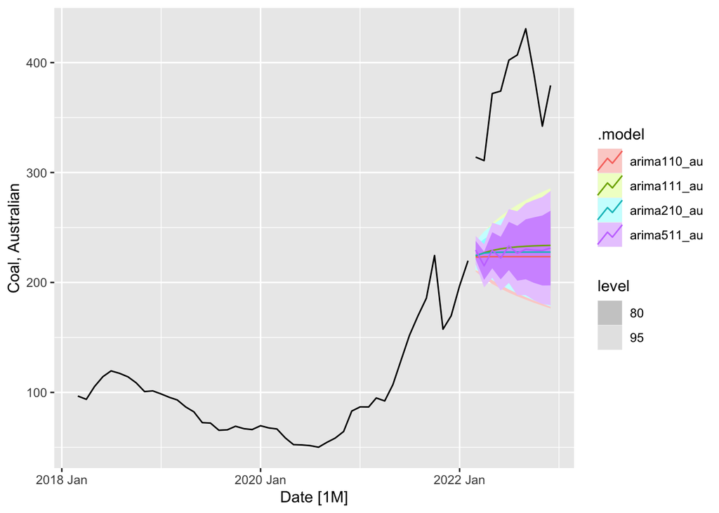

```r
autoplot(data_au_ts_plot) + autolayer(forecast_h10) + autolayer(data_test_au)
```

Just visually, there is almost no difference between the variables, so we need to check manually with bias calculation and loss functions what is better.

Bias:

```r
#what we had before:
summary(fit_resid_arima111)
```

```
##
## Call:
## lm(formula = Volat_au_111 ~ forecast_h10$.mean[21:30])
##
## Residuals:
##     Min      1Q  Median      3Q     Max
## -53.756 -14.676   2.562  19.452  40.366
##
## Coefficients:
##                            Estimate Std. Error t value Pr(>|t|)
## (Intercept)               -1645.174    699.755  -2.351   0.0466 *
## forecast_h10$.mean[21:30]     7.740      3.031   2.553   0.0340 *
## ---
## Signif. codes:  0 '***' 0.001 '**' 0.01 '*' 0.05 '.' 0.1 ' ' 1
##
## Residual standard error: 29.25 on 8 degrees of freedom
## Multiple R-squared:  0.449,  Adjusted R-squared:  0.3801
## F-statistic: 6.519 on 1 and 8 DF,  p-value: 0.034
```

```r
#the model was biased. let's check this one
volat_au_garch <- data_3_tsb$`Coal, South African` - data_model_au_wo_diff$au_price_no_diff

#let's check its estimate
mean(volat_au_garch)
```

```
## [1] 89.58113
```

Now, lets find the bias itself:

```r
bias_au <- lm(volat_au_garch ~ data_model_au_wo_diff$au_price_no_diff)
summary(bias_au)
```

```
##
## Call:
## lm(formula = volat_au_garch ~ data_model_au_wo_diff$au_price_no_diff)
##
## Residuals:
##     Min      1Q  Median      3Q     Max
## -36.534  -4.711   4.363  11.287  14.021
##
## Coefficients:
##                                        Estimate Std. Error t value Pr(>|t|)
## (Intercept)                            -2821.19    3285.37  -0.859    0.415
## data_model_au_wo_diff$au_price_no_diff    13.01      14.68   0.886    0.401
##
## Residual standard error: 16.27 on 8 degrees of freedom
## Multiple R-squared:  0.08935,    Adjusted R-squared:  -0.02448
## F-statistic: 0.785 on 1 and 8 DF,  p-value: 0.4015
```

Other parameters:

```r
RMSE_garch <- (sum((volat_au_garch)^2/length((volat_au_garch)))^(1/2))
RMSE_garch
```

```
## [1] 90.87034
```

```r
MAE_garch <- sum(abs(volat_au_garch))/length(volat_au_garch)
MAE_garch
```

```
## [1] 89.58113
```

```r
MAPE_garch <- sum(abs(volat_au_garch/data_model_au_wo_diff$au_price_no_diff))/length(data_model_au_wo_diff$au_price_no_diff)
MAPE_garch*100
```

```
## [1] 40.03537
```

lets see what we had:

```r
fabletools::accuracy(forecast_h10, data_1_tsb) %>%
  select(.model | RMSE:MAPE)
```

```
## # A tibble: 4 × 5
##   .model       RMSE   MAE   MPE  MAPE
##   <chr>       <dbl> <dbl> <dbl> <dbl>
## 1 arima110_au  153.  149.  39.3  39.3
## 2 arima111_au  146.  141.  37.4  37.4
## 3 arima210_au  150.  145.  38.3  38.3
## 4 arima511_au  149.  145.  38.3  38.3
```

**Comments:**

### Forecast with GARCH.

```r
garch_for2023_Spec_au = ugarchspec(variance.model=list(model="sGARCH", garchOrder=c(1,1)),
              mean.model=list(armaOrder=c(1,1),
              include.mean=T))

garch_for2023_Fit_au <- ugarchfit(spec = garch_for2023_Spec_au, data = data_au_ts_fore2023_copy$au_price_diff)

forecast2023_garch_au <- ugarchboot(garch_for2023_Fit_au, method = c("Partial","Full")[1],
                            n.ahead = 12, n.bootpred = 1000, n.bootfit = 1000)

f_garch_au_2023 <- forecast2023_garch_au@forc@forecast$seriesFor

sigma_au_f <- forecast2023_garch_au@forc@forecast$sigmaFor[1]
high_au <- f_garch_au_2023 + 1.96*sigma_au
low_au <- f_garch_au_2023 - 1.96*sigma_au
```

Lets now get it back to the regular values form:

```r
data_au_ts_fore2023_copy[(nrow(data_au_ts_fore2023_copy)-1):nrow(data_au_ts_fore2023_copy),]
```

```
## # A tsibble: 2 x 3 [1M]
##   `Coal, Australian`     Date au_price_diff
##                <dbl>    <mth>         <dbl>
## 1               342. 2022 Nov         -47.6
## 2               379. 2022 Dec          37.1
```

```r
data_model_au_wo_diff2023 <- as.data.frame(f_garch_au_2023)

data_model_au_wo_diff2023 <- data_model_au_wo_diff2023 %>%
  rename(., 'au_price_no_diff' = `1971-04-14 03:00:00`)

data_model_au_wo_diff2023$au_price_no_diff[1] <- data_model_au_wo_diff2023$au_price_no_diff[1] + data_au_ts_fore2023_copy$`Coal, Australian`[nrow(data_au_ts_fore2023_copy)]

for (t in (2:12)) {
  data_model_au_wo_diff2023$au_price_no_diff[t] = data_model_au_wo_diff2023$au_price_no_diff[t] + data_model_au_wo_diff2023$au_price_no_diff[t-1]
}

x <- seq(as.Date("2023-01-01"), as.Date("2023-12-31"), by = "1 month")
Date <- yearmonth(x)

data_model_au_wo_diff2023$Date <- Date
```

```r
df_test_3 <- data_au_ts_fore2023_copy %>%
  rename(., "au_price_no_diff" =`Coal, Australian`)

df_test_3 <- df_test_3[,c("Date","au_price_no_diff")]

df_test_4 <- data_model_au_wo_diff2023[,c("Date","au_price_no_diff")]

df_test_4 <- as.data.frame(df_test_4)

df_test_5 <- bind_rows(df_test_3,df_test_4)
```

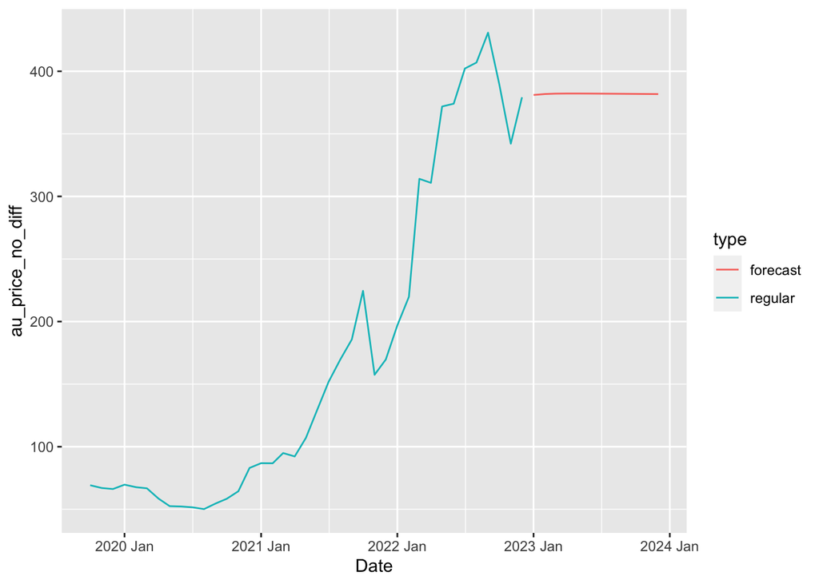

```r
df_test_5$type <- ifelse(df_test_5$Date %in% Date, 'forecast','regular')

ggplot(df_test_5[(nrow(df_test_5)-50):nrow(df_test_5),], aes(x = Date,y = au_price_no_diff, col=type)) +
  geom_line()
```